# Hockey Match Report

Analyst’s Diary Match Report

# Slovakia vs Norway

**16 May 2026**  
IIHF World Championship 2026 – Group Stage

Slovakia (SVK) 2:1 Norway (NOR)

Report generated from the match shot-location pipeline. Metrics marked as proxies are based on OCR-extracted shot coordinates and should be interpreted as transparent spatial indicators rather than official tracking data.

Prepared by Antonin Kremenak

# Executive summary

Shots On Goal

NOR: 23 | SVK: 19

Blocked Shots

NOR: 9 | SVK: 16

Scoring Chances

NOR: 7 | SVK: 12

# 1. Public layer: simple match metrics

These visuals are designed as a simple entry point for wider audiences: official shots on goal, blocked shots, shot quality proxies and basic chance creation.

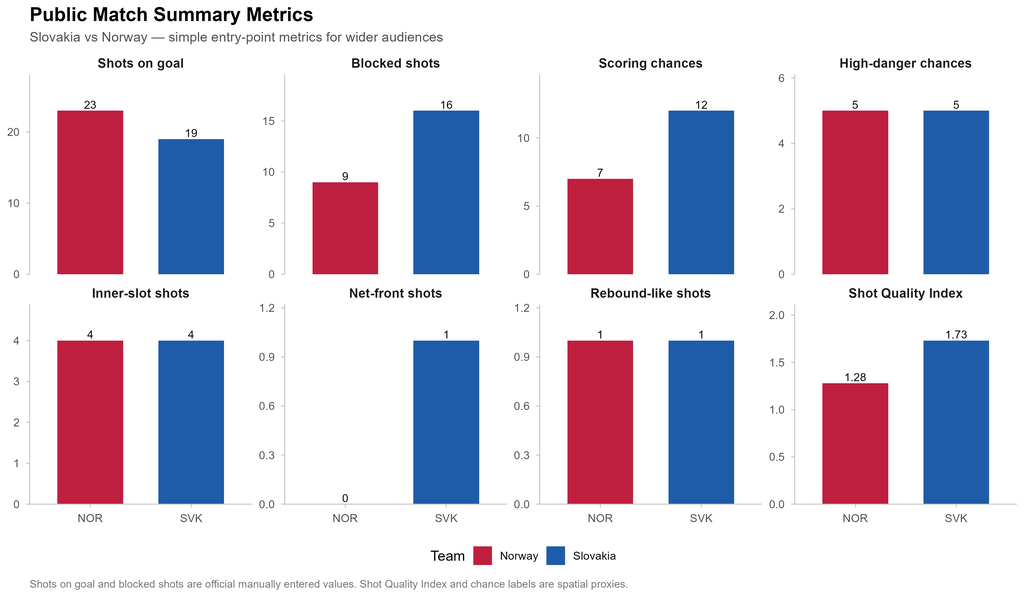

Key Metrics: Slovakia vs Norway

16 May 2026 — Shot Quality Index is a location-based proxy, not a trained xG model.

| Metric | SVK | NOR |
| --- | --- | --- |
| OCR detected attempts | 29.00 | 19.00 |
| Corsi attempts | 29.00 | 19.00 |
| Fenwick attempts | 21.00 | 16.00 |
| Scoring chances | 12.00 | 7.00 |
| High-danger chances | 5.00 | 5.00 |
| Shot Quality Index | 1.73 | 1.28 |

# 2. Shot maps and spatial overview

Shot maps show where attempts came from, how dangerous they were spatially, and how shot locations changed across periods.

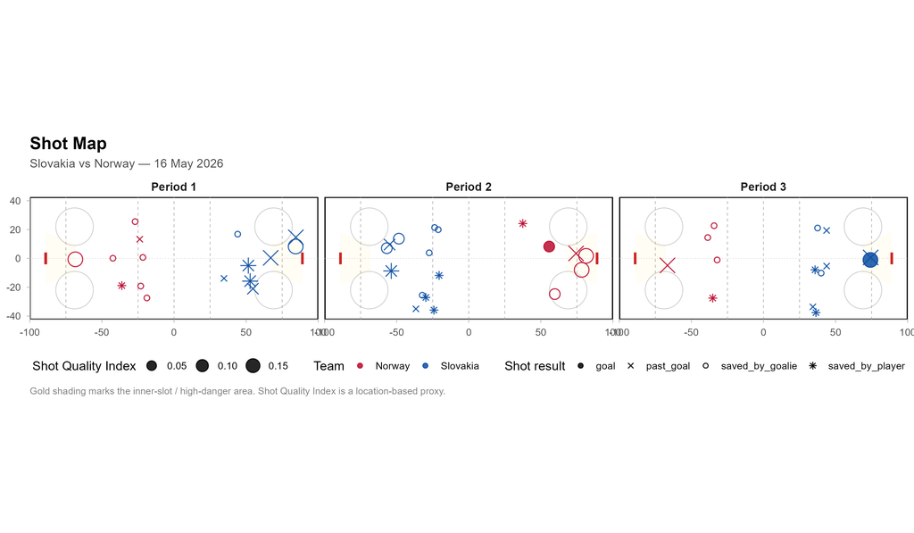

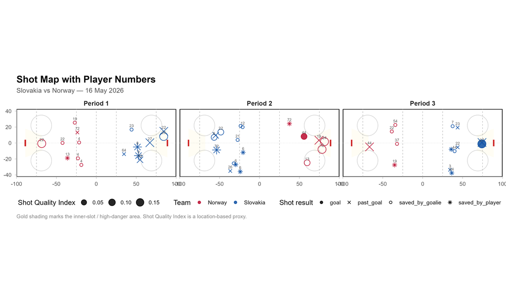

# 3. Shot quality and territorial battle

This section moves from simple shot counts to spatial pressure: location quality, offensive-zone density and period-by-period territorial advantage.

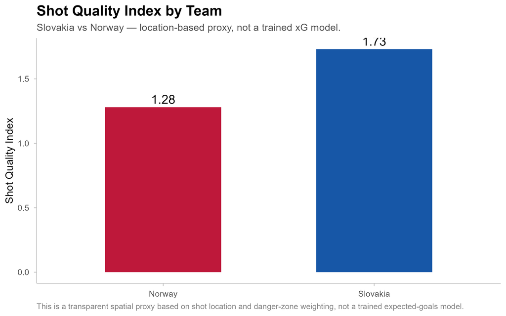

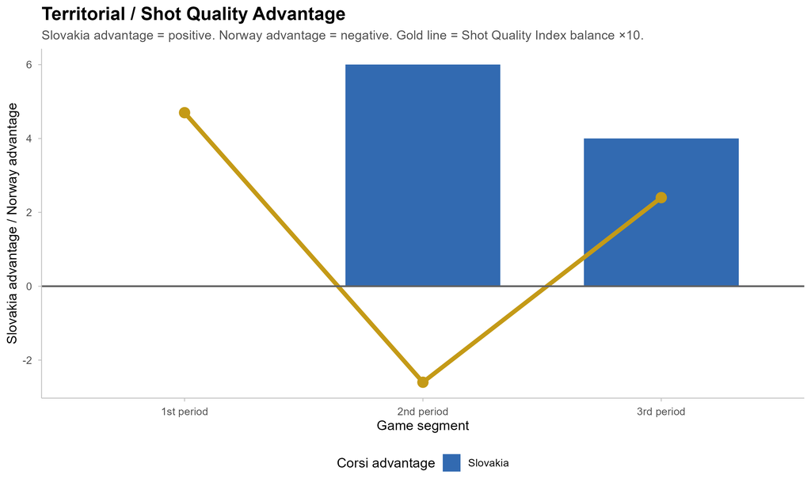

# 4. Offensive-zone density

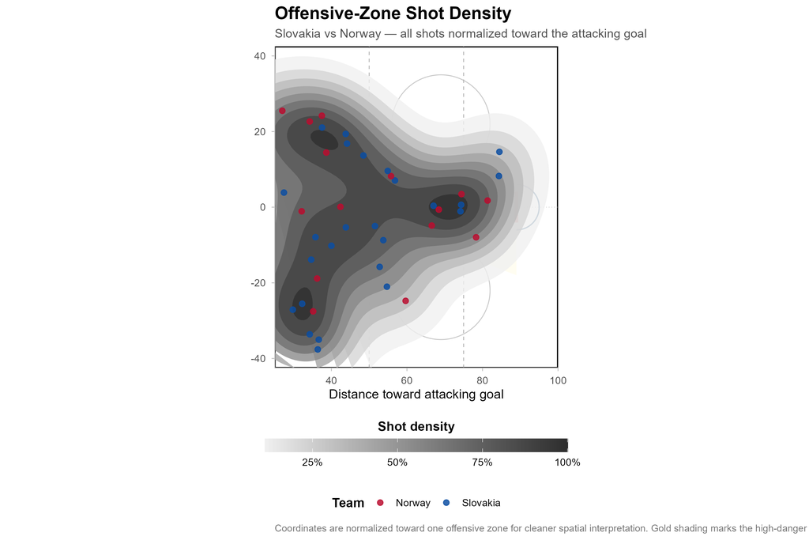

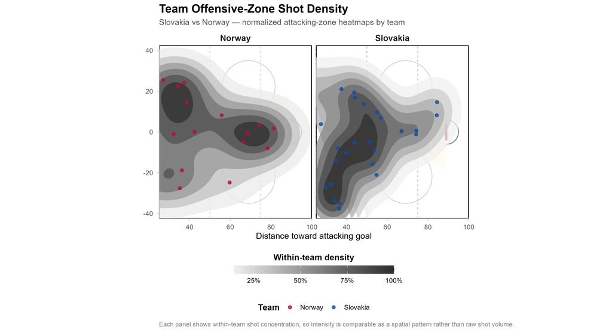

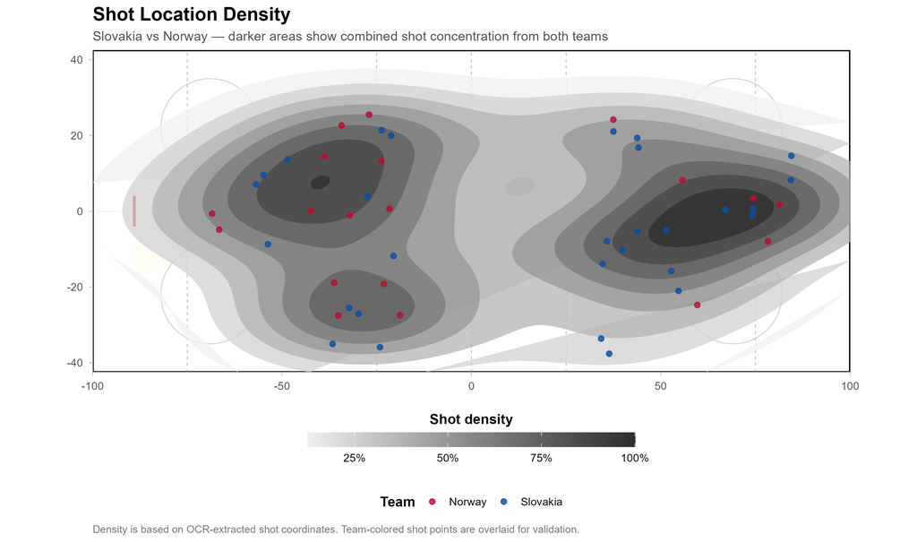

# 5. Advanced insider layer

The following metrics are proxy-based insider indicators built from the available shot-location sample. They are useful for storytelling, but they are not a substitute for full play-by-play or tracking data.

- Norway showed the highest aggression profile while tied, based on chance rate, slot access and net-front pressure.
- Norway had the strongest danger-oriented shot style: slot-heavy / chance-driven.
- Norway generated the clearest central-access pattern: strong central-lane access.
- Norway produced the strongest pressure window between shot sequence 24 and 29.
- Norway had the highest goals-per-SQI finishing efficiency and roughly aligned with chance quality.

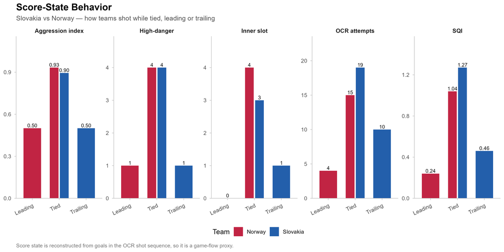

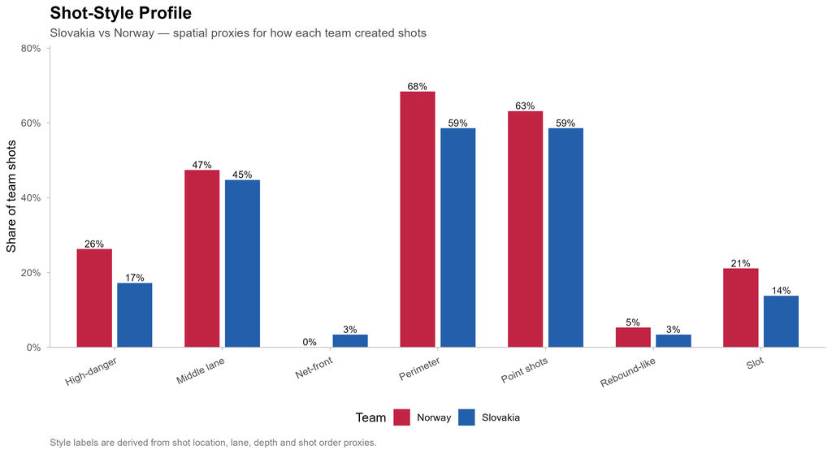

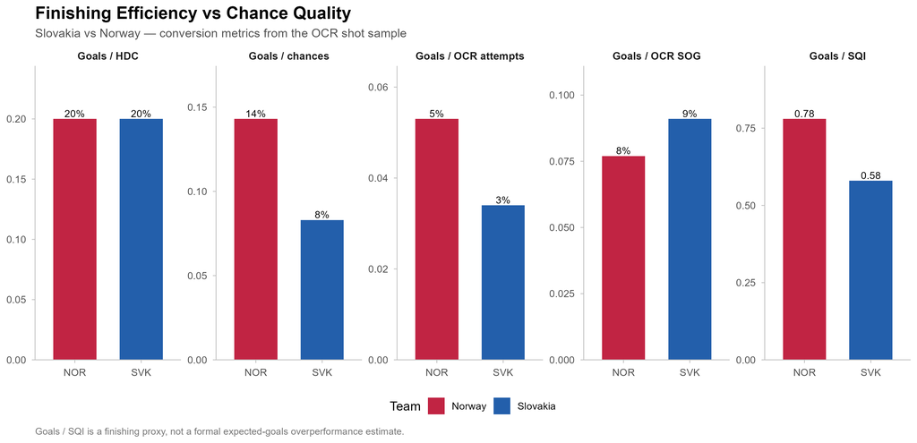

# 6. Momentum

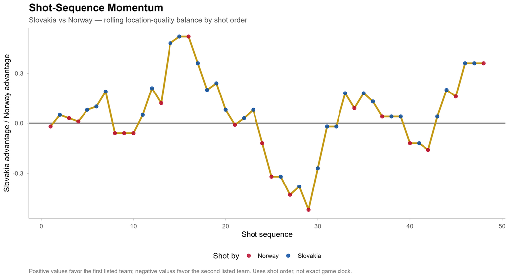

# 7. Player layer

**Player public leaders**

Top players from the OCR-extracted shot sample

| team | player_no | ocr_detected_attempts | ocr_shots_on_goal | scoring_chances | high_danger_chances | inner_slot_shots | net_front_shots | rebound_like_shots | shot_quality_index | avg_shot_distance | team_name |
| --- | --- | --- | --- | --- | --- | --- | --- | --- | --- | --- | --- |
| SVK | 27 | 2 | 1 | 2 | 2 | 1 | 0 | 0 | 0.36 | 18.4 | Slovakia |
| SVK | 22 | 3 | 1 | 2 | 1 | 1 | 0 | 0 | 0.27 | 34.5 | Slovakia |
| NOR | 44 | 2 | 1 | 2 | 1 | 0 | 0 | 0 | 0.25 | 28.6 | Norway |
| SVK | 8 | 2 | 0 | 2 | 1 | 1 | 0 | 1 | 0.25 | 26.2 | Slovakia |
| NOR | 19 | 3 | 1 | 1 | 1 | 1 | 0 | 0 | 0.22 | 47.5 | Norway |
| NOR | 22 | 3 | 3 | 1 | 1 | 1 | 0 | 0 | 0.22 | 39.9 | Norway |
| SVK | 23 | 3 | 2 | 1 | 1 | 1 | 1 | 0 | 0.22 | 35.5 | Slovakia |
| NOR | 12 | 1 | 1 | 1 | 1 | 1 | 0 | 0 | 0.18 | 13.3 | Norway |
| NOR | 24 | 1 | 1 | 1 | 1 | 1 | 0 | 1 | 0.18 | 7.9 | Norway |
| SVK | 6 | 4 | 1 | 1 | 0 | 0 | 0 | 0 | 0.13 | 60.4 | Slovakia |
| NOR | 13 | 2 | 1 | 1 | 0 | 0 | 0 | 0 | 0.09 | 47.2 | Norway |
| SVK | 64 | 4 | 1 | 0 | 0 | 0 | 0 | 0 | 0.08 | 60.8 | Slovakia |

# Source

https://www.iihf.com/en/events/2026/wm/schedule